# Week 2 Recitation Notes

Natalie Kerr

Notes from discussion with Sara: - Get rid of `seq()`, `sample()`, and `rep()`. They’ll do sampling online later. - Switch `rnorm()` to `runif()`. They don’t know the normal distribution yet, but having a random number generator in R could be handy. - Do summary stats with dplyr - Do some plot types not found in Chapter 2 to review `ggplot2` (e.g. violin plots) - Teach reading csvs. Use `read_csv()` instead of `read.csv()` maybe

# Moved from week 1:

## Data Entry (Eric)

Before uploading data, you have to have all files in the same folder as this notebook for this code to run.

```r
read.csv("SpiderAmputation.csv") # uploads your data
```

But if you want it to stick around, you need to assign to an object!

```r
data <- read.csv("SpiderAmputation.csv")
#or call it whatever you want
data
```

Always a good idea to check your data to make sure it loaded correctly

```r
head(data) # will call up the first 6 rows of your data frame
tail(data) # will call up the last 6 rows of your data frame
data[1:10, ] # data[rows, columns] therefore data[1:10, ] will call up rows 1 to 10, and all columns
```

Other ways to check your data

```r
str(data) # shows what kind of data is in each column (character, integer, etc.). Helpful for spotting data entry errors
dim(data) # the dimensions of your data frame
nrow(data) # number of rows
ncol(data) # number of columns
length(data[ , 1]) # length of a vector or column in your data frame. You will have to specify the column if it is a data frame.
```

You can see the objects you’ve created in the Environment panel

## Descriptive Stats (Natalie)

```r
summary(data$speed)

mean(data$speed)
sd(data$speed)
var(data$speed)
min(data$speed)
max(data$speed)
range(data$speed) # IMPORTANT: in this class, "range" is a single value (min - max)

before<-subset(data, treatment=="before")
mean(before$speed)

after<-subset(data, treatment=="after")
mean(after$speed)
```

### 1. Notebook saving

1. Create notebook and save somewhere.
2. Move it and click “no”
3. Show that it creates a new file, but keeps the old one open
4. Move it and show that you need to click “yes”
5. Show them on trunk that you can download the homework, and use that file.

### 2. Warmup (lecture slides)

```r
bee<-read.csv("BeeNectar.csv")
nrow(bee)
```

```
[1] 525
```

```r
summary(bee$Nectar)
```

```
   Min. 1st Qu.  Median    Mean 3rd Qu.    Max.
0.00027 0.01943 0.03249 0.03475 0.04740 0.13928
```

```r
mean(bee$Nectar)
```

```
[1] 0.03475465
```

```r
sd(bee$Nectar)
```

```
[1] 0.02086053
```

```r
var(bee$Nectar)
```

```
[1] 0.0004351615
```

```r
sqrt(var(bee$Nectar))
```

```
[1] 0.02086053
```

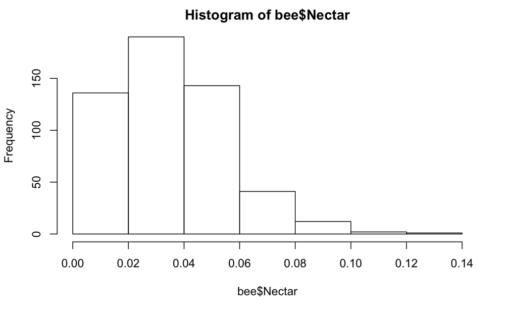

```r
hist(bee$Nectar, breaks=8)
```

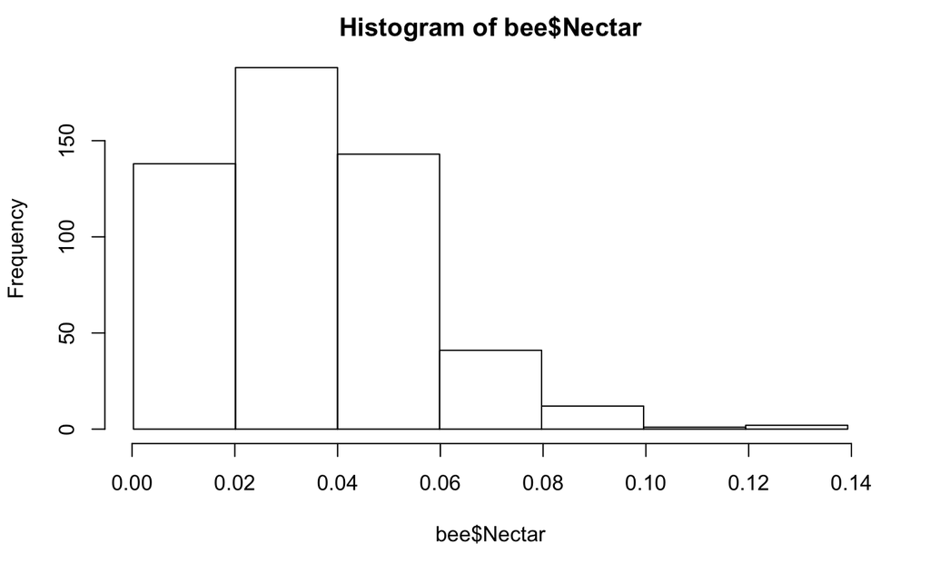

```r
hist(bee$Nectar, breaks=seq(min(bee$Nectar),max(bee$Nectar), length.out=8))
```

- **Histogram binning**: Rules of Thumb (**always** use this guideline in this class!)

| Sample Size | Number of Bins |
| --- | --- |
| Less than 16 | Not Enough Data |
| 16–31 | 5 |
| 32–63 | 6 |
| 64–127 | 7 |
| 128–255 | 8 |

### 3. Guided learning

#### 3a.Introduce seq and sample

```r
num<-seq(1, 10, 1) # sequence of numbers, ranging from = to = and by =
num<-seq(1, 10, length.out=5)
seq(min(bee$Nectar),
    max(bee$Nectar),
    length.out=8) # select for number of "breaks" or bins
```

```
[1] 0.00027000 0.02012857 0.03998714 0.05984571 0.07970429 0.09956286 0.11942143 0.13928000
```

```r
sample(num, 2)
```

```
[1]  7.75 10.00
```

#### 3b. Introduce repeating function

Not equal numbers. Hat full of marbles, and you know the number of each. Randomly sample from the hat!

```r
y<-rep("yellow", 20)
r<-rep("red", 5)
b<-rep("blue", 100)
color<-c(y, r, b)
sample(color, 10)
```

```
 [1] "blue"   "blue"   "blue"   "yellow" "blue"   "blue"   "blue"   "blue"   "blue"
[10] "yellow"
```

```r
rep(5, 22)
```

```
 [1] 5 5 5 5 5 5 5 5 5 5 5 5 5 5 5 5 5 5 5 5 5 5
```

```r
rep(c(5, 10), 11)
```

```
 [1]  5 10  5 10  5 10  5 10  5 10  5 10  5 10  5 10  5 10  5 10  5 10
```

```r
rep(c(5, 10, 33), each = 3)
```

```
[1]  5  5  5 10 10 10 33 33 33
```

```r
rep(c("A", "B", "C"), 3)
```

```
[1] "A" "B" "C" "A" "B" "C" "A" "B" "C"
```

```r
rep(c("A", "B", "C"), each = 3)
```

```
[1] "A" "A" "A" "B" "B" "B" "C" "C" "C"
```

```r
rep(c("A", "B", "C"), length.out=11)
```

```
 [1] "A" "B" "C" "A" "B" "C" "A" "B" "C" "A" "B"
```

### 4. EXERCISE 1: sampling from Nectar column or rows in dataset.

```r
ten<-sample(bee$Nectar, 10)
fo<-sample(bee$Nectar, 40)
mean(ten)
```

```
[1] 0.037898
```

```r
mean(fo)
```

```
[1] 0.03510125
```

```r
mean(bee$Nectar)
```

```
[1] 0.03475465
```

```r
# Solution 1 for rows in dataset
sim<-seq(1, 525, 1)
sim<-seq(1, nrow(bee), 1)
bee[sample(sim, 10),]
```

|  | Colony | BeeID | Pollen | ITS | Nectar |
| --- | --- | --- | --- | --- | --- |
| 61 | 2 | Y98-WT | 0.00232 | 3.66 | 0.00991 |
| 302 | 57 | B70 | 0.00388 | 3.68 | 0.03680 |
| 209 | 57 | B91-GT | 0.00000 | 3.34 | 0.02794 |
| 420 | 58 | G77 | 0.00000 | 3.57 | 0.05089 |
| 111 | 43 | W68 | 0.00000 | 3.96 | 0.01635 |
| 258 | 2 | Y32 | 0.02310 | 3.89 | 0.03217 |
| 483 | 2 | Y11 | 0.00000 | 4.25 | 0.06256 |
| 444 | 57 | B24 | 0.00000 | 4.36 | 0.05594 |
| 494 | 57 | B87 | 0.00000 | 4.41 | 0.06682 |
| 515 | 32 | R-OT | 0.00000 | 3.30 | 0.08665 |

```r
# Solution 2 for rows in dataset
bee[sample(1:525, 10), ]
```

|  | Colony | BeeID | Pollen | ITS | Nectar |
| --- | --- | --- | --- | --- | --- |
| 484 | 35 | 988E52010B000000 | 0 | 4.05 | 0.06283 |
| 318 | 41 | 5BAC52010B000000 | 0 | 3.18 | 0.03877 |
| 409 | 43 | W72 | 0 | 4.13 | 0.04959 |
| 260 | 35 | DBAC52010B000000 | 0 | 3.87 | 0.03235 |
| 27 | 2 | Y45 | 0 | 3.55 | 0.00458 |
| 479 | 57 | B4-OT | 0 | 3.42 | 0.06154 |
| 410 | 2 | Y77 | 0 | 4.09 | 0.04972 |
| 211 | 43 | W62 | 0 | 3.44 | 0.02820 |
| 306 | 35 | 70AC52010B000000 | 0 | 3.78 | 0.03735 |
| 408 | 57 | B73 | 0 | 3.91 | 0.04915 |

```r
bee[sample(1:nrow(bee), 40), ]
```

|  | Colony | BeeID | Pollen | ITS | Nectar |
| --- | --- | --- | --- | --- | --- |
| 199 | 35 | C68F52010B000000 | 0.00000 | 3.63 | 0.02733 |
| 447 | 57 | B87 | 0.00000 | 4.41 | 0.05609 |
| 436 | 35 | 849652010B000000 | 0.00000 | 3.82 | 0.05483 |
| 180 | 41 | 958F52010B000000 | 0.00000 | 3.18 | 0.02550 |
| 159 | 43 | W64 | 0.00000 | 3.46 | 0.02273 |
| 369 | 35 | 629752010B000000 | 0.00000 | 3.82 | 0.04377 |
| 16 | 35 | 508D52010B000000 | 0.00000 | 3.99 | 0.00306 |
| 472 | 57 | B62-OT | 0.01123 | 3.57 | 0.06043 |
| 33 | 2 | Y23 | 0.00255 | 3.23 | 0.00588 |
| 403 | 35 | B89C52010B000000 | 0.00202 | 4.14 | 0.04864 |

[output cut: 30 more lines]

```r
nrow(bee) # tells you how many rows in your dataset
```

```
[1] 525
```

### 5. Introduce rnorm() that randomly generates numbers given some specified mean and standard deviation

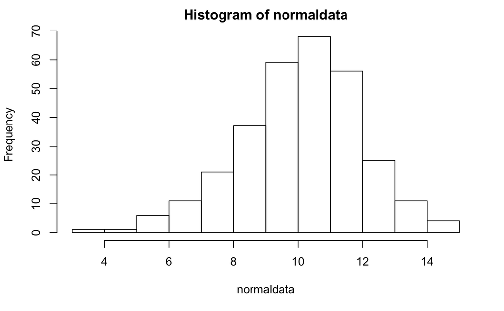

```r
normaldata<-rnorm(300, mean=10, sd=2) # run this a few times, what do you notice?
hist(normaldata)
```

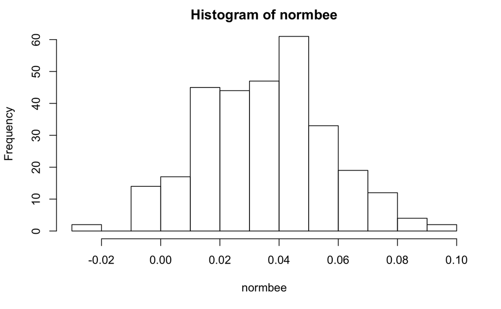

```r
# DO YOU THINK YOUR BEE DATA IS NORMALLY DISTRIBUTED??
normbee<-rnorm(300, mean=mean(bee$Nectar), sd=sd(bee$Nectar)) # Enter in your mean and standard from the nectar weight
hist(normbee) # Negative values
```

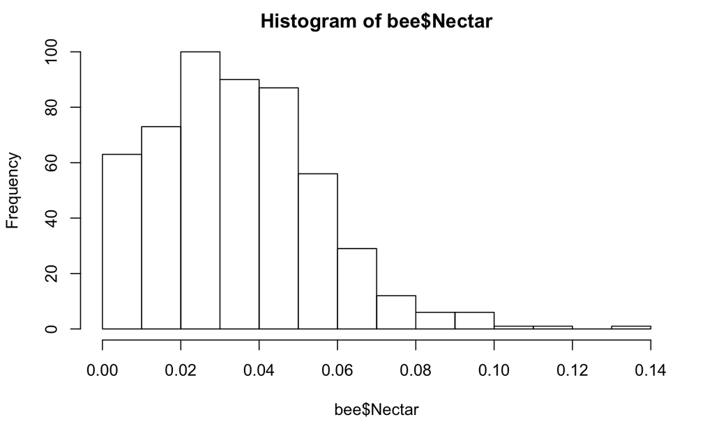

```r
hist(bee$Nectar) # No, positively skewed
```

### 6. EXERCISE 2. Create a boxplot of the nectar weight of bees from different colonies

```r
class(bee$Colony)
```

```
[1] "integer"
```

```r
bee$Colony<-as.factor(bee$Colony)
class(bee$Colony)
```

```
[1] "factor"
```

```r
# A. Summary stats
summary(bee$Pollen)
```

```
    Min.  1st Qu.   Median     Mean  3rd Qu.     Max.
0.000000 0.000000 0.000000 0.001994 0.000000 0.038210
```

```r
summary(bee$ITS)
```

```
   Min. 1st Qu.  Median    Mean 3rd Qu.    Max.    NA's
   2.80    3.58    3.82    3.84    4.07    5.32       1
```

```r
sd(bee$Pollen)
```

```
[1] 0.005320508
```

```r
sd(bee$ITS, na.rm=T)
```

```
[1] 0.4045449
```

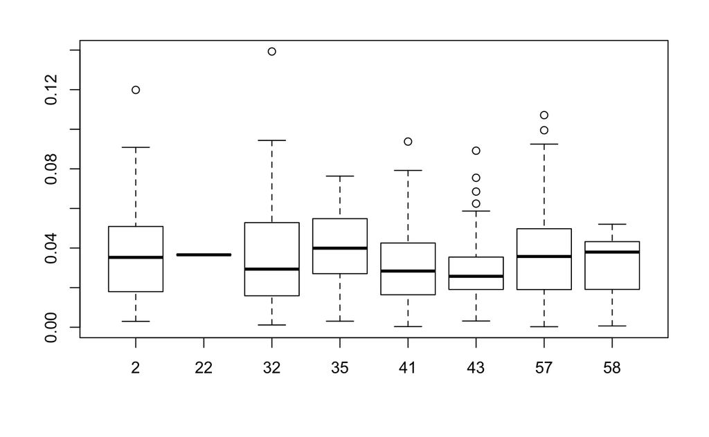

```r
# B. Boxplots
with(bee, boxplot(Nectar ~ Colony))
```

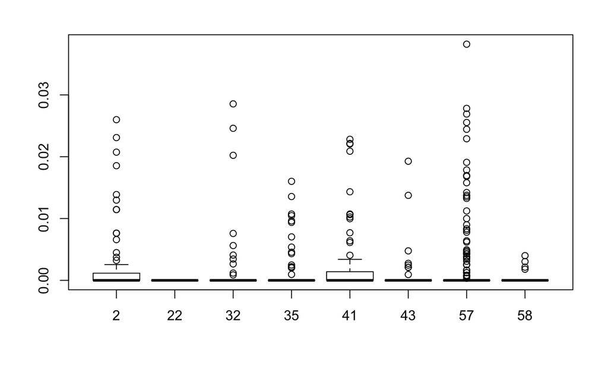

```r
with(bee, boxplot(Pollen ~ Colony))
```

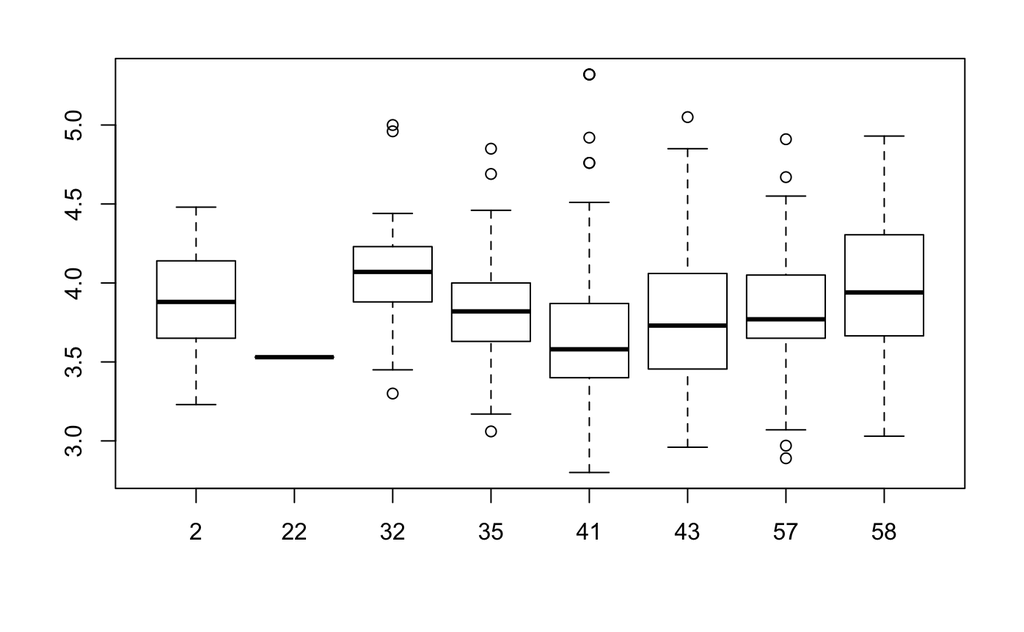

```r
with(bee, boxplot(ITS ~ Colony))
# C. Advanced problem
library(tidyverse)
```

```r
new.data<-bee %>% group_by(Colony) %>% summarise(mu.nec = round(mean(Nectar), 6),
                                                 sd.nec = round(sd(Nectar), 6),
                                                 mu.poll = round(mean(Pollen), 6),
                                                 sd.poll = round(sd(Pollen), 6),
                                                 range.nec = round(max(Nectar) - min(Nectar), 6))
```

Common problems

```r
# 1. Subsetting data to create a new dataset
sub1 <- subset(bee, Pollen == 0) # all values that are 0, you need double ==
sub2 <- subset(bee, Pollen > 0) # all values greater than
sub3 <- subset(bee, Pollen >= 0.01) # equal to or greater than
sub4 <- subset(bee, Pollen > 0.01 | Pollen < 0.0002) # keep values that are either (1) greater than 0.01 or less than 0.0002
sub5 <- subset(bee, Colony == "32") # factors (e.g. categorical variables should have quotations)
sub6 <- subset(bee, Colony =="32" & Pollen > 0)  # you can combine data
# 2. Removing NA values
sub7 <- subset(bee, !is.na(ITS)) # remove all rows in dataset where ITS has NA values.
mean(bee$ITS, na.rm=T) # or remove NAs just in function, so that you keep all these rows for analysing other vectors, e.g. Nectar and Pollen.
```

```
[1] 3.840191
```

```r
# 3. Classes of variables
class(bee$Pollen) # tells you the class of variable that is listed within the Pollen column
```

```
[1] "numeric"
```

```r
is.factor(bee$Pollen) # Pollen is not a factor
```

```
[1] FALSE
```

```r
is.numeric(bee$Pollen) # Pollen is listed as numeric -- good!
```

```
[1] TRUE
```

```r
is.factor(bee$Colony) # If "TRUE" then good, if "FALSE" then bad
```

```
[1] TRUE
```

```r
bee$Colony <- as.factor(bee$Colony) # To make colony ID column as a factor
```

| Lecture speak | R speak |
| --- | --- |
| Numerical, continuous | numeric |
| Numerical, discrete | integer |
| Categorical, nominal | factor (or character) |
| Categorical, ordinal | factor (with `levels` specified) |

It is better to leave all categorical vectors as factors for statistical tests, e.g. ANOVA.